# Penghitungan gradien otomatis (autograd)

Ingat kembali bahwa dalam melatih *machine learning* kita perlu menghitung turunan dari *loss function* terhadap **semua parameter pada model**. Untuk *machine learning* yang sederhana, kita masih bisa menghitung secara manual kemudian membuat programnya. Saat arsitektur *machine learning* sudah mulai dalam, belasan hingga puluhan *layer*, dan terdapat banyak operasi yang rumit (hingga yang tak biasa), menghitung turunan secara manual akan sangat memakan waktu. Belum lagi, sebagai manusia, kita rentan melakukan kesalahan. Maka dari itu, biarkan komputer yang melakukan penghitungan diferensiasi untuk kita.

**Catatan**

Penulis berasumsi bahwa pembaca dapat memahami *mental model* dasar dari suatu struktur data ndarray. Pembahasan ndarray dicukupkan, dan pada bagian ini kita sudah bisa beralih menggunakan NumPy agar dapat melakukan komputasi dengan lebih cepat.

## Autograd numerik

Dengan autograd numerik, kita mencari aproksimasi dari suatu turunan dari fungsi. Metode autograd numerik paling sederhana adalah *Newton’s difference quotient* yang dijabarkan sebagai berikut:

$$f'(x) = \lim_{h\to 0} \frac{f(x+h) - f(x)}{h}$$

Dalam python, kita dapat membuat implementasi paling sederhananya sebagai berikut:

```python
def grad(f, h):
    def grad_f(x):
        return (f(x + h) - f(x)) / h
    return grad_f

# Fungsi kuadrat
def f(x):
    return x ** 2

f_grad = grad(f, h=0.0000001)

print("f(x) = x ** 2")
print("f(3) =", f(3))
print("f'(3) =", f_grad(3))
```

```
f(x) = x ** 2
f(3) = 9
f'(3) = 6.000000087880153
```

Semakin kecil nilai `h`, maka aproksimasi lebih akurat.

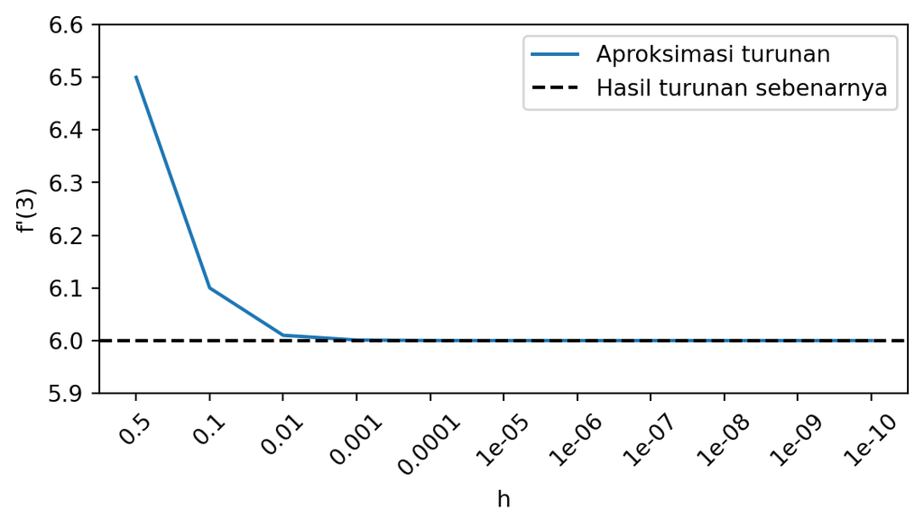

Algoritma *machine learning* modern **menghindari** penggunaan autograd numerik, karena:

- Tentu saja, karena tidak eksak. Hal ini akan mengakibatkan error (karena kesalahan pembulatan) yang cukup serius, khususnya dengan fungsi/model yang lebih kompleks.
- Lambat. Setidaknya, kompleksitas waktu yang dibutuhkan adalah $O(n^2)$.

## Autograd eksak

[output not shown]

*Leave* dari graf adalah tensor-tensor input, dan *root* adalah output. Dengan melakukan *tracing* dari *root* ke *leave*, kita dapat secara otomatis menghitung gradien. Autograd eksak berbasis graf komputasi ini dapat dieksekusi dengan kompleksitas waktu linear.

# Autograd eksak dengan mode *forward*

# Autograd eksak dengan mode *backward*